# final_SL2

## Supervised Learning Assessment 2

## Setup and Imports

```python
import pandas as pd
import numpy as np
import matplotlib.pyplot as plt
import seaborn as sns
from scipy import stats


from sklearn.preprocessing import StandardScaler
from sklearn.decomposition import PCA
from sklearn.linear_model import Lasso, Ridge, ElasticNet, LinearRegression
from sklearn.ensemble import RandomForestRegressor, GradientBoostingRegressor
from sklearn.pipeline import Pipeline
from sklearn.model_selection import GroupKFold, GridSearchCV, cross_val_score
from sklearn.metrics import mean_squared_error, r2_score

import warnings
warnings.filterwarnings('ignore')

# Reproducibility
np.random.seed(270)
```

## Part 1: Exploratory Data Analysis

### 1.1 Load and Inspect Data

We load both datasets upfront. Key structural observations:

- Training: 4000 samples (rows) * 42 columns (y, group_id, X1-X40)
- Test: 1000 samples (rows) * 41 columns (obs_id, X1-X40). No y and no group_id
- The test set comes from laboratories that are not present in training, so our model must generalise across batch effects.

```python
# Load data

train = pd.read_csv('train1.csv')
test = pd.read_csv('test_public.csv')

train.head()
```

|  | y | group_id | X1 | X2 | X3 | X4 | X5 | X6 | X7 | X8 | ... | X31 | X32 | X33 | X34 | X35 | X36 | X37 | X38 | X39 | X40 |
| --- | --- | --- | --- | --- | --- | --- | --- | --- | --- | --- | --- | --- | --- | --- | --- | --- | --- | --- | --- | --- | --- |
| 0 | 11.654607 | 3 | 0.058543 | 0.723556 | 0.153003 | 0.457480 | 0.319631 | 0.077587 | 0.554313 | 0.123066 | ... | 0.096031 | 0.959691 | 0.223233 | 0.990661 | 0.230771 | 0.792535 | 0.663730 | 0.642548 | 0.154105 | 0.596182 |
| 1 | 13.507191 | 18 | 0.249930 | 0.606075 | 0.946025 | 0.247700 | 0.388893 | 0.995804 | 0.535626 | 0.236658 | ... | 0.656679 | 0.868502 | 0.054951 | 0.553600 | 0.224968 | 0.135391 | 0.140219 | 0.618970 | 0.393401 | 0.479746 |
| 2 | 7.899599 | 34 | 0.595112 | 0.919922 | 0.518477 | 0.735384 | 0.218200 | 0.558822 | 0.345468 | 0.387678 | ... | 0.842935 | 0.484479 | 0.115632 | 0.514526 | 0.642767 | 0.062567 | 0.248837 | 0.295473 | 0.335310 | 0.885759 |
| 3 | 8.235798 | 3 | 0.839775 | 0.790372 | 0.229852 | 0.074056 | 0.142260 | 0.025440 | 0.863692 | 0.881676 | ... | 0.189331 | 0.956846 | 0.806054 | 0.990795 | 0.541368 | 0.927557 | 0.412567 | 0.700743 | 0.119422 | 0.872536 |
| 4 | 19.832434 | 20 | 0.618705 | 0.618912 | 0.093913 | 0.839131 | 0.779727 | 0.771520 | 0.503339 | 0.009146 | ... | 0.326868 | 0.683929 | 0.300116 | 0.932801 | 0.105080 | 0.258285 | 0.364386 | 0.419618 | 0.034804 | 0.579149 |

5 rows × 42 columns

```python
test.head()
```

|  | obs_id | X1 | X2 | X3 | X4 | X5 | X6 | X7 | X8 | X9 | ... | X31 | X32 | X33 | X34 | X35 | X36 | X37 | X38 | X39 | X40 |
| --- | --- | --- | --- | --- | --- | --- | --- | --- | --- | --- | --- | --- | --- | --- | --- | --- | --- | --- | --- | --- | --- |
| 0 | 1 | 0.206395 | 0.294569 | 0.431523 | 0.989990 | 0.057044 | 0.299027 | 0.219255 | 0.441452 | 0.471100 | ... | 0.944158 | 0.145927 | 0.148148 | 0.843033 | 0.132174 | 0.979002 | 0.498764 | 0.928613 | 0.574074 | 0.089457 |
| 1 | 2 | 0.510168 | 0.500771 | 0.862616 | 0.674699 | 0.024871 | 0.105511 | 0.419991 | 0.740541 | 0.021499 | ... | 0.439216 | 0.210617 | 0.363765 | 0.456293 | 0.462467 | 0.960016 | 0.597397 | 0.941994 | 0.510742 | 0.524615 |
| 2 | 3 | 0.067564 | 0.039627 | 0.980569 | 0.386323 | 0.042997 | 0.062026 | 0.329777 | 0.532527 | 0.090166 | ... | 0.025214 | 0.433324 | 0.022085 | 0.056366 | 0.533499 | 0.953696 | 0.827900 | 0.887644 | 0.668153 | 0.598666 |
| 3 | 4 | 0.106187 | 0.161077 | 0.348888 | 0.841643 | 0.051611 | 0.317739 | 0.321272 | 0.770096 | 0.295292 | ... | 0.392441 | 0.164754 | 0.704513 | 0.349595 | 0.330636 | 0.938008 | 0.394728 | 0.844287 | 0.743559 | 0.963964 |
| 4 | 5 | 0.649431 | 0.293986 | 0.498518 | 0.067994 | 0.121219 | 0.132130 | 0.072232 | 0.547735 | 0.938101 | ... | 0.169980 | 0.232901 | 0.735642 | 0.082774 | 0.716376 | 0.936439 | 0.551601 | 0.960880 | 0.396726 | 0.410349 |

5 rows × 41 columns

```python
features = [f'X{i}' for i in range(1, 41)]

print("Structure of the datasets:")
print(f"features: {features}")
print(f"Training:  {train.shape[0]} rows * {train.shape[1]} columns")
print(f"Test:      {test.shape[0]} rows * {test.shape[1]} columns")
print(f"\nTraining columns: {list(train.columns)}")
print(f"Test columns:     {list(test.columns[:5])}")
print(f"\nUnique groups: {train['group_id'].nunique()} unique")
print(f"Samples per group: {train.groupby('group_id').size().unique()[0]}")
print(f"\nMissing values in train: {train.isnull().sum().sum()}, test: {test.isnull().sum().sum()}")
```

```
Structure of the datasets:
features: ['X1', 'X2', 'X3', 'X4', 'X5', 'X6', 'X7', 'X8', 'X9', 'X10', 'X11', 'X12', 'X13', 'X14', 'X15', 'X16', 'X17', 'X18', 'X19', 'X20', 'X21', 'X22', 'X23', 'X24', 'X25', 'X26', 'X27', 'X28', 'X29', 'X30', 'X31', 'X32', 'X33', 'X34', 'X35', 'X36', 'X37', 'X38', 'X39', 'X40']
Training:  4000 rows * 42 columns
Test:      1000 rows * 41 columns

Training columns: ['y', 'group_id', 'X1', 'X2', 'X3', 'X4', 'X5', 'X6', 'X7', 'X8', 'X9', 'X10', 'X11', 'X12', 'X13', 'X14', 'X15', 'X16', 'X17', 'X18', 'X19', 'X20', 'X21', 'X22', 'X23', 'X24', 'X25', 'X26', 'X27', 'X28', 'X29', 'X30', 'X31', 'X32', 'X33', 'X34', 'X35', 'X36', 'X37', 'X38', 'X39', …
Test columns:     ['obs_id', 'X1', 'X2', 'X3', 'X4']

Unique groups: 40 unique
Samples per group: 100

Missing values in train: 0, test: 0
```

Our main interesting takeaway here is that there are no missing values, so we do not need to perform any preprocessing for this.

### 1.2 Response Variable

We check the distribution of y to see whether transformations (e.g. log) are needed and what loss functions are appropriate.

```python
print(train['y'].describe())
```

```
count    4000.000000
mean       14.505666
std         4.989890
min         1.926941
25%        10.733942
50%        14.702663
75%        18.389920
max        28.110356
Name: y, dtype: float64
```

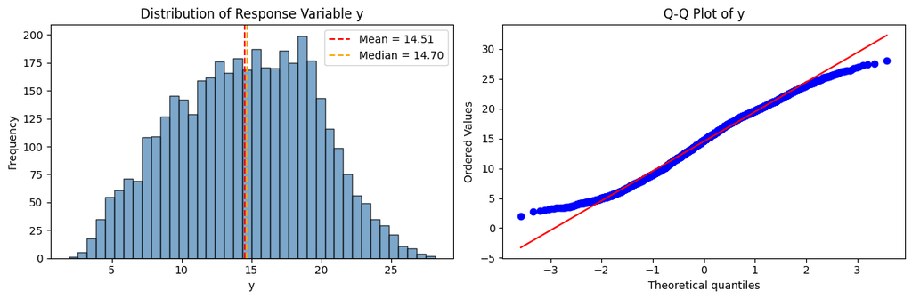

```python
fig, axes = plt.subplots(1, 2, figsize=(12, 4))

# Histogram
axes[0].hist(train['y'], bins=40, edgecolor='black', alpha=0.7, color='steelblue')
axes[0].axvline(train['y'].mean(), color='red', ls='--', label=f"Mean = {train['y'].mean():.2f}")
axes[0].axvline(train['y'].median(), color='orange', ls='--', label=f"Median = {train['y'].median():.2f}")
axes[0].set_xlabel('y')
axes[0].set_ylabel('Frequency')
axes[0].set_title('Distribution of Response Variable y')
axes[0].legend()

# QQ plot
stats.probplot(train['y'], plot=axes[1])
axes[1].set_title('Q-Q Plot of y')
plt.tight_layout()
plt.show()
```

```python
print(f"Skewness: {train['y'].skew():.3f}")
print(f"Kurtosis: {train['y'].kurtosis():.3f}")
```

```
Skewness: -0.059
Kurtosis: -0.682
```

We find that the distribution is approximately symmetric and close to gaussian, indicating that no transformation is needed for y

### 1.3 Feature Distributions and Skewness

We check the distribution of our features. From research, gene expression data can often be right-skewed, and so may require transformation.

```python
# Summary statistics
desc = train[features].describe().T[['mean', 'std', 'min', 'max']]
print(desc)
```

```
         mean       std       min       max
X1   0.501740  0.289908  0.000000  1.000000
X2   0.497783  0.289327  0.000000  1.000000
X3   0.496400  0.288591  0.000000  0.999409
X4   0.500078  0.289424  0.000000  1.000000
X5   0.514672  0.281848  0.000000  1.000000
X6   0.511565  0.276339  0.000315  0.999232
X7   0.499945  0.288877  0.000000  1.000000
X8   0.500085  0.287493  0.000000  1.000000
X9   0.503759  0.289193  0.000254  1.000000
X10  0.504767  0.288417  0.000000  1.000000
X11  0.485264  0.286559  0.000000  1.000000
X12  0.500044  0.287859  0.000000  1.000000
X13  0.462382  0.277688  0.000000  0.987028
X14  0.499749  0.287732  0.000000  1.000000
X15  0.498829  0.288914  0.000000  0.999775
X16  0.499051  0.289734  0.000000  1.000000
X17  0.499598  0.288854  0.000000  1.000000
X18  0.501037  0.289195  0.000354  1.000000
X19  0.486073  0.284921  0.000000  1.000000
X20  0.499208  0.287728  0.000000  1.000000
X21  0.499343  0.289391  0.000000  1.000000
X22  0.500754  0.289680  0.000000  1.000000
X23  0.496549  0.290857  0.000000  1.000000
X24  0.497153  0.286751  0.000000  1.000000
X25  0.501624  0.290540  0.000691  1.000000
X26  0.502400  0.288241  0.000000  1.000000
X27  0.501492  0.288012  0.000000  1.000000
X28  0.499174  0.289601  0.000000  0.999599
X29  0.505322  0.283587  0.000196  1.000000
X30  0.498267  0.288046  0.000000  0.999366
X31  0.501916  0.288962  0.000000  1.000000
X32  0.511826  0.290777  0.000000  1.000000
X33  0.500574  0.288314  0.000155  0.999930
X34  0.500976  0.288051  0.000000  0.999515
X35  0.501342  0.288651  0.000000  1.000000
X36  0.461997  0.273766  0.000000  1.000000
X37  0.462261  0.288553  0.000000  0.994828
X38  0.459122  0.282513  0.000000  1.000000
X39  0.496075  0.288248  0.000000  1.000000
X40  0.498282  0.288506  0.000000  1.000000
```

```python
# Skewness
skew = train[features].skew()
print(f"Range: [{skew.min():.3f}, {skew.max():.3f}]")
print(f"Max |skewness|: {skew.abs().max():.3f}")
print(f"Features with |skewness| > 1: {(skew.abs() > 1).sum()}")
print(f"Features with |skewness| > 2: {(skew.abs() > 2).sum()}")
```

```
Range: [-0.081, 0.199]
Max |skewness|: 0.199
Features with |skewness| > 1: 0
Features with |skewness| > 2: 0
```

We find that all features in our dataset have a range of [0,1] indicating they may already be pre-processed or transformed. They also exhibit near-zero skewness.

If we choose to use regularised models, like Lasso which applies a penalty to coefficients, we may not need any scaling. As all features share a common range, gross differences are absent here. However, we may still find residual variance differences, and so, standardScalar may be useful. It is standard practice, and would be harmless even if useless in this scenario.

Log-transformations are unneccessary due to the absence of skewness.

### 1.4 Batch Effects

Since each laboratory uses different equipment/protocols, measurements from the same lab may share systematic biases, termed batch effects by the assignment brief. TThis can lead to misleading effects, particularly in validation.

- If batch effects are large, standard K-Fold CV as a validation could be overly optimistic as training and validation share labs.
- The test set comes from unseen labs, so we should try to generalise across batch effects.

```python
# How much does y vary BETWEEN labs vs WITHIN labs?
group_stats = train.groupby('group_id')['y'].agg(['mean', 'std'])

print(f"Overall y descriptors:  mean = {train['y'].mean():.2f}, std = {train['y'].std():.2f}")
print("lab means descriptors:")
print(f"range = [{group_stats['mean'].min():.2f}, {group_stats['mean'].max():.2f}]")
print(f"Std of lab means: {group_stats['mean'].std():.2f}")
print(f"Mean of within-lab stds: {group_stats['std'].mean():.2f}")

print(f"\nRatio (between-lab var / total var): {group_stats['mean'].var() / train['y'].var():.2f}")
```

```
Overall y descriptors:  mean = 14.51, std = 4.99
lab means descriptors:
range = [6.25, 23.03]
Std of lab means: 4.55
Mean of within-lab stds: 2.13

Ratio (between-lab var / total var): 0.83
```

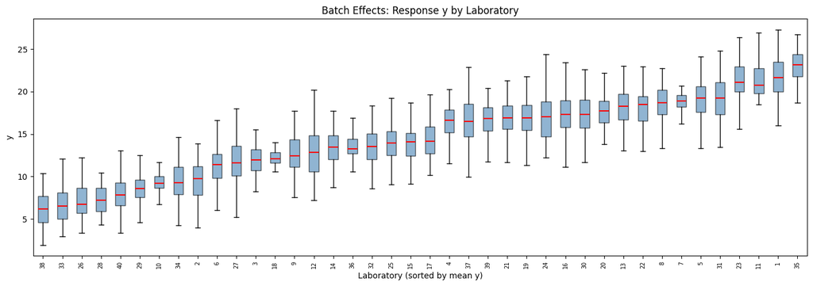

```python
# Visualise
fig, ax = plt.subplots(figsize=(14, 5))
group_order = group_stats['mean'].sort_values().index
bp = ax.boxplot([train[train['group_id']==g]['y'].values for g in group_order],
                patch_artist=True, showfliers=False,
                medianprops=dict(color='red', linewidth=1.5))
for patch in bp['boxes']:
    patch.set_facecolor('steelblue')
    patch.set_alpha(0.6)
ax.set_xlabel('Laboratory (sorted by mean y)')
ax.set_ylabel('y')
ax.set_title('Batch Effects: Response y by Laboratory')
ax.set_xticks(range(1, 41))
ax.set_xticklabels([str(g) for g in group_order], rotation=90, fontsize=7)
plt.tight_layout()
plt.show()
```

We find a couple of interesting takeaways.

Our lab means range of [6.25, 23.03] indicates that the average y value differs greatly across labs.

83% of the variation seen in y can be determined from the lab sample it came from. Only 17% is within lab variation. This poses a problem for Standard K-Fold.

As Standard K-Fold splits observations randomly, observations for one lab may land in both the training and validation fold. The model would be able to correctly predict the structure of one lab, but may not learn the actual biology of the dataset - i.e. be able to predict the gene-expression within labs.

This would lead to a model performing well within validation, but only learning which lab a given sample belongs to, rather than the gene expression and response relationships.

We choose to mitigate these effects by using GroupKFold for our validation method instead. This ensures that the observations in a given lab are either places in training or validation only, and not split across both, allowing us to generalise these batch effects across labs, and leading to a more accurate cross-validated MSE.

### 1.5 Feature-Response Correlations

We further evaluate the structure of our dataset, identifying which genes are most linearly associated with y.

This will help us select features for our models, as well as whether a spare or dense model is more appropriate.

```python
# Correlations with y
corr_y = train[features + ['y']].corr()['y'].drop('y').sort_values(key=abs, ascending=False)
print("feature Correlations with y:")
print(corr_y.head(15).round(4))
print(f"\nFeatures with |r| > 0.3: {(corr_y.abs() > 0.3).sum()}")
print(f"Features with |r| > 0.1: {(corr_y.abs() > 0.1).sum()}")
print(f"Features with |r| < 0.05: {(corr_y.abs() < 0.05).sum()}")
```

```
feature Correlations with y:
X5     0.6190
X6     0.5888
X29    0.5766
X19    0.3697
X36   -0.3429
X13    0.3243
X37    0.2763
X11   -0.1452
X32    0.1408
X22   -0.1197
X2    -0.0954
X38   -0.0912
X33    0.0866
X20   -0.0824
X7    -0.0725
Name: y, dtype: float64

Features with |r| > 0.3: 6
Features with |r| > 0.1: 10
Features with |r| < 0.05: 22
```

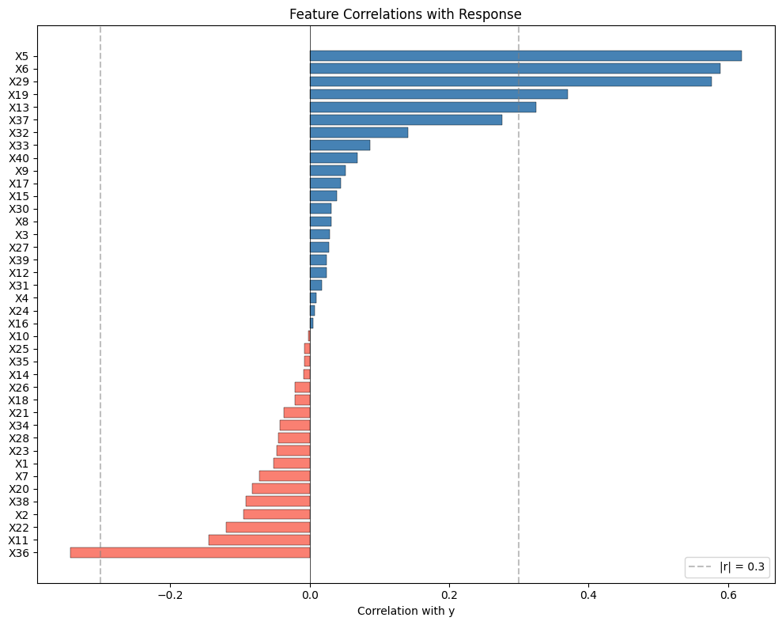

```python
# Bar chart
fig, ax = plt.subplots(figsize=(10, 8))
corr_sorted = corr_y.sort_values(ascending=True)  # for horizontal bar
colors = ['steelblue' if v > 0 else 'salmon' for v in corr_sorted]
ax.barh(corr_sorted.index, corr_sorted.values, color=colors, edgecolor='black', linewidth=0.3)
ax.set_xlabel('Correlation with y')
ax.set_title('Feature Correlations with Response')
ax.axvline(0, color='black', linewidth=0.5)
ax.axvline(0.3, color='grey', ls='--', alpha=0.5, label='|r| = 0.3')
ax.axvline(-0.3, color='grey', ls='--', alpha=0.5)
ax.legend()
plt.tight_layout()
plt.show()
```

We find that the Signal is concentrated in around 6 genes (X5, X6, X29, X19, X36, X13).

### 1.6 Multicollinearity Check

In multiple linear regression, we estimate coeficients using OLS. High correlation between features can cause inflated variance, and so OLS coefficients become unreliable and highly sensitive to small changes in the data. We check for multicollinearity and see if our OLS estimates may affect the accuracy of our predictors.

```python
# Inter-feature correlations
corr_matrix = train[features].corr()
upper = corr_matrix.where(np.triu(np.ones(corr_matrix.shape), k=1).astype(bool))
high_corr = [(c, r, upper.loc[r, c]) for c in upper.columns for r in upper.index
             if abs(upper.loc[r, c]) > 0.5]
high_corr.sort(key=lambda x: abs(x[2]), reverse=True)

print("Multicollinearity Check")
print(f"Feature pairs with |r| > 0.7: {sum(1 for _,_,v in high_corr if abs(v)>0.7)}")
print(f"Feature pairs with |r| > 0.5: {len(high_corr)}")

print("\nHighest inter-feature correlations:")
for c, r, v in high_corr[:10]:
    print(f"{c} - {r}: r = {v:.2f}")
```

```
Multicollinearity Check
Feature pairs with |r| > 0.7: 0
Feature pairs with |r| > 0.5: 7

Highest inter-feature correlations:
X29 - X19: r = 0.69
X37 - X13: r = 0.59
X38 - X5: r = -0.55
X38 - X11: r = 0.53
X38 - X36: r = 0.52
X36 - X11: r = 0.51
X37 - X19: r = 0.50
```

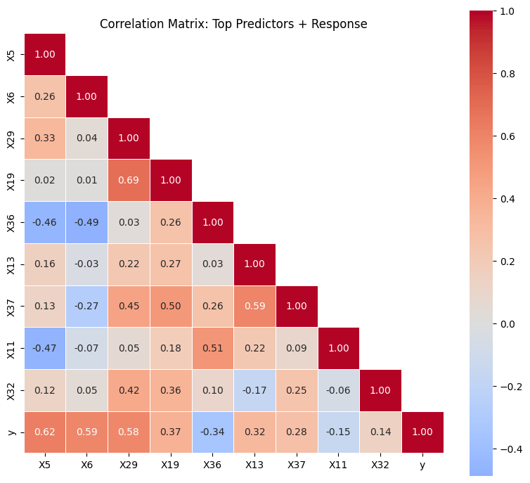

```python
# Heatmap of top predictors
top = ['X5', 'X6', 'X29', 'X19', 'X36', 'X13', 'X37', 'X11', 'X32', 'y']
fig, ax = plt.subplots(figsize=(8, 7))
mask = np.triu(np.ones((len(top), len(top)), dtype=bool), k=1)
sns.heatmap(train[top].corr(), annot=True, fmt='.2f', cmap='coolwarm', center=0,
            mask=mask, square=True, ax=ax, linewidths=0.5)
ax.set_title('Correlation Matrix: Top Predictors + Response')
plt.tight_layout()
plt.show()
```

Key takeaways here:

- No severe multicollinearity (i.e. no pairs above |r| = 0.7).
- Top predictors (X5, X6, X29) are not strongly correlated with each other.

Multicollinearity is moderate here. Lasso would not be impacted greatly (tendency to arbitrarily pick correlated pairs). Ridges L2 penalty means multicollinearity is also not an issue here.

### 1.7 PCA: Dimensionality and Laboratory Clustering

PCA is performed to gain further insight into the structure of our data. We are looking for two different things:

1. Whether the data lies on a low-dimensional subspace, which may indicate that PCR with few components could work well.
2. Identifying if our laboratories cluster in PC space, which would confirm batch effects exist in the feature space, not just in y.

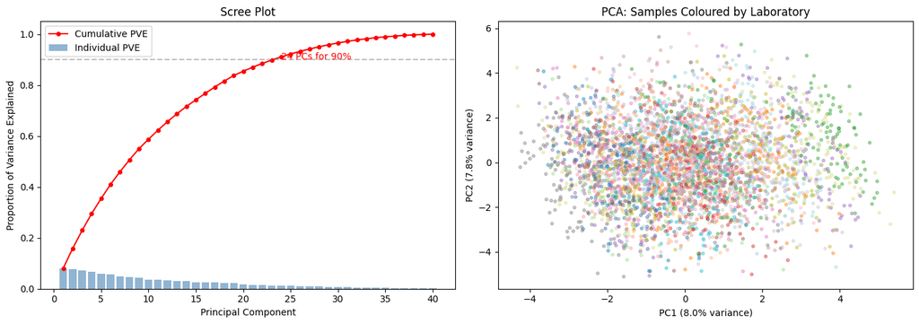

```python
scaler_eda = StandardScaler()
X_scaled_eda = scaler_eda.fit_transform(train[features])

# Full PCA
pca_full = PCA().fit(X_scaled_eda)
pve = pca_full.explained_variance_ratio_
cum_pve = np.cumsum(pve)
n90 = np.argmax(cum_pve >= 0.9) + 1
n95 = np.argmax(cum_pve >= 0.95) + 1

fig, axes = plt.subplots(1, 2, figsize=(14, 5))

# Scree plot
axes[0].bar(range(1, 41), pve, alpha=0.6, color='steelblue', label='Individual PVE')
axes[0].plot(range(1, 41), cum_pve, 'ro-', markersize=4, label='Cumulative PVE')
axes[0].axhline(0.9, ls='--', color='grey', alpha=0.5)
axes[0].set_xlabel('Principal Component')
axes[0].set_ylabel('Proportion of Variance Explained')
axes[0].set_title('Scree Plot')
axes[0].legend()
axes[0].annotate(f'{n90} PCs for 90%', xy=(n90, 0.9), fontsize=10, color='red')

# PCA scatter coloured by lab
pca_2d = PCA(n_components=2)
pcs = pca_2d.fit_transform(X_scaled_eda)
scatter = axes[1].scatter(pcs[:, 0], pcs[:, 1], c=train['group_id'], cmap='tab20', alpha=0.4, s=10)
axes[1].set_xlabel(f'PC1 ({pca_2d.explained_variance_ratio_[0]*100:.1f}% variance)')
axes[1].set_ylabel(f'PC2 ({pca_2d.explained_variance_ratio_[1]*100:.1f}% variance)')
axes[1].set_title('PCA: Samples Coloured by Laboratory')

plt.tight_layout()
plt.show()
```

```python
print(f"Components for 90% variance: {n90}")
print(f"Components for 95% variance: {n95}")
print(f"First 5 PCs explain: {cum_pve[4]*100:.1f}%")
```

```
Components for 90% variance: 24
Components for 95% variance: 28
First 5 PCs explain: 35.4%
```

The scree plot shows no clear elbow, with 24 components needed for 90% variance.This means the data has no useful low-dimensional structure, which makes PCR a poor choice here.

The PCA scatter shows labs do not cluster in feature space, confirming batch effects live in y and not the feature space, which may reduce the severity of these batch effects and the generalisation problem.

Our variance structure has a large spread, indicating favour for Lasso over PCR, as there is no clustering of labs.

## Part 2: Model Development and Interpretation

### Preperation and preprocessing

```python
# Prepare data
X_train = train[features].values
y_train = train['y'].values
groups = train['group_id'].values
X_test = test[features].values

# Each fold holds out ~4 entire laboratories (4 × 100 = 400 samples)
gkf = GroupKFold(n_splits=10)

# Verify fold structure
for i, (tr_idx, val_idx) in enumerate(gkf.split(X_train, y_train, groups)):
    val_labs = sorted(np.unique(groups[val_idx]))
    if i < 3:
        print(f"Fold {i+1}: Train {len(tr_idx)} samples | Validate {len(val_idx)} samples | Held-out labs: {val_labs}")

results = {}
```

```
Fold 1: Train 3600 samples | Validate 400 samples | Held-out labs: [np.int64(10), np.int64(20), np.int64(30), np.int64(40)]
Fold 2: Train 3600 samples | Validate 400 samples | Held-out labs: [np.int64(9), np.int64(19), np.int64(29), np.int64(39)]
Fold 3: Train 3600 samples | Validate 400 samples | Held-out labs: [np.int64(8), np.int64(18), np.int64(28), np.int64(38)]
```

n_splits=10 holds out exactly 4 labs per fold, giving 400 validation samples, which is large enough for a stable MSE estimate while keeping 3600 training samples per fold.

GroupKFold is used instead of standard KFold because the 83% between-lab variance shown in the EDA section.

Passing groups=train['group_id'].values mnakes sure that all observations from the same laboratory stay together, preventing leakage back to standard KFold behaviour.

### 2.1 Model 1: Lasso Regression (L1 Penalty)

The EDA showed signal concentrated in ~6 genes. Lasso's L1 penalty shrinks irrelevant coefficients exactly to zero, performing automatic variable selection. From our EDA, this makes Lasso a good potential model.

It can provide us with:

- A sparse, interpretable model, signalling which genes matter for responses.
- Protection against overfitting, as we have many other features.

$\alpha$ controls regularisation strength, i.e. larger $\alpha$ mean that more coefficients are discarded.

We select the value of $\alpha$ based on searching through 50 values on a log-scale from $10^{-4}$ to 10.

```python
lasso_alphas = np.logspace(-4, 1, 50)

lasso_pipe = Pipeline([
    ('scaler', StandardScaler()),
    ('lasso', Lasso(max_iter=10000)) #to avoid convergence warnings for small alphas
])

lasso_grid = GridSearchCV(
    lasso_pipe,
    param_grid={'lasso__alpha': lasso_alphas},
    cv=gkf,
    scoring='neg_mean_squared_error',
    n_jobs=-1,
    return_train_score=True
)
lasso_grid.fit(X_train, y_train, groups=groups)

# Extract results
lasso_cv_mse = -lasso_grid.cv_results_['mean_test_score']
lasso_cv_std = lasso_grid.cv_results_['std_test_score']
lasso_train_mse = -lasso_grid.cv_results_['mean_train_score']

best_lasso_alpha = lasso_grid.best_params_['lasso__alpha']
best_lasso_mse = -lasso_grid.best_score_
best_lasso_std = lasso_cv_std[lasso_grid.best_index_]

print(f"Best alpha: {best_lasso_alpha:.6f}")
print(f"CV MSE:     {best_lasso_mse:.4f} ± {best_lasso_std:.4f}")

# Refit at best alpha to inspect coefficients
lasso_final = Pipeline([('scaler', StandardScaler()), ('lasso', Lasso(alpha=best_lasso_alpha, max_iter=10000))])
lasso_final.fit(X_train, y_train)
lasso_coefs = pd.Series(lasso_final.named_steps['lasso'].coef_, index=features)

print(f"\nNon-zero coefficients: {(lasso_coefs != 0).sum()}/40")
print("\nSelected genes (sorted by |coefficient|):")
print(lasso_coefs[lasso_coefs != 0].sort_values(key=abs, ascending=False).round(4))

results['Lasso'] = {'mse': best_lasso_mse, 'std': best_lasso_std, 'model': lasso_final}
```

```
Best alpha: 0.091030
CV MSE:     5.7816 ± 3.0508

Non-zero coefficients: 8/40

Selected genes (sorted by |coefficient|):
X6     2.6011
X29    1.8251
X5     1.6206
X37    0.8226
X32   -0.4680
X13    0.3503
X19    0.1033
X1     0.0027
dtype: float64
```

### 2.2 Model 2: Gradient Boosting

Our EDA showed that Lasso is a natural choice, by suggesting the model is sparse due to only a few predictive features.

We compliment this with gradient boost, as our 83% between-lab variance, and a failure of linear structures explaining y could mean that non-linear structures are present. Our PCA seems to support this hypothesis: labs did not cluster in the 2D PCA space, and variance was widely spread out, so they may cluster in higher dimensions.

Gradient boosting builds trees sequentially, and so may be able to capture these non-linear patterns better. So while both models are wildly different, they allow us to approach the dataset from two different directions.

```python
gb_pipe = Pipeline([
    ('gb', GradientBoostingRegressor(random_state=270))
])

gb_grid = GridSearchCV(
    gb_pipe,
    param_grid={
        'gb__n_estimators': [100, 300],
        'gb__learning_rate': [0.05, 0.1],
        'gb__max_depth': [3, 5],
        'gb__min_samples_leaf': [10, 20],
        'gb__subsample': [0.8]
    },
    cv=gkf,
    scoring='neg_mean_squared_error',
    n_jobs=-1,
    return_train_score=True
)
gb_grid.fit(X_train, y_train, groups=groups)

best_gb_mse = -gb_grid.best_score_
best_gb_std = gb_grid.cv_results_['std_test_score'][gb_grid.best_index_]

print(f"Best params: {gb_grid.best_params_}")
print(f"CV MSE:      {best_gb_mse:.4f} ± {best_gb_std:.4f}")

# Feature importance
gb_final = gb_grid.best_estimator_
gb_final.fit(X_train, y_train)
gb_importance = pd.Series(gb_final.named_steps['gb'].feature_importances_, index=features)
print("\nTop 10 features by importance:")
print(gb_importance.sort_values(ascending=False).head(10).round(4))

results['Gradient Boosting'] = {'mse': best_gb_mse, 'std': best_gb_std, 'model': gb_final}
```

```
Best params: {'gb__learning_rate': 0.1, 'gb__max_depth': 3, 'gb__min_samples_leaf': 20, 'gb__n_estimators': 300, 'gb__subsample': 0.8}
CV MSE:      0.9357 ± 0.2665

Top 10 features by importance:
X5     0.3723
X6     0.2297
X29    0.2029
X32    0.0720
X37    0.0578
X13    0.0350
X19    0.0235
X11    0.0034
X22    0.0004
X38    0.0002
dtype: float64
```

#### Parameter justification

n_estimators: [100, 300]:

- Controls the number of sequential trees. 100 and 300 bracket the typical range for a dataset of this size, we also tried 500 but removed it after excessive runtime for diminishing results.

learning_rate: [0.05, 0.1]:

- Each tree's contribution to the final prediction is multiplied by this value before the next tree is fitted. A smaller learning rate means each tree corrects errors more cautiously, requiring more trees to converge but generally producing a better regularised model.

max_depth: [3, 5]:

- Controls how many feature interactions each tree can capture. Depth 3 allows three-way interactions (e.g. X5 * X6 * X29). Depth 5 allows deeper interactions but risks overfitting.

min_samples_leaf: [10, 20]:

- Sets the minimum number of observations required in each last node of a tree. Higher values prevent the model from making splits that represent only a handful of lab-specific observations, which then acts as a regulariser against overfitting. We choose conservative values here, as we only have roughly 100 obs per lab.

subsample: [0.8]:

- tree is fitted on a random 80% of the training data rather than the full dataset, introducing randomness that reduces overfitting. Fixed at 0.8 rather than searched, leading to a minimal cost to bias, while cutting down on processing time.

### 2.3 Sanity checks for very low MSE

Much lower than the 4.54 floor in EDA, this is very suspicious, so some checks here are made to verify if this result is due to a leakage error.

```python
# Verify groups are being passed correctly
print(groups[:10])  # should show lab IDs, not None
print(len(groups))  # should equal len(X_train) = 4000

# Then rerun with explicit groups
gb_grid.fit(X_train, y_train, groups=groups)
print(-gb_grid.best_score_)  # should be in range 4.5 - 8.0
```

```
[ 3 18 34  3 20  9  4 19  9  5]
4000
0.9357057044531981
```

```python
print(X_train.shape)   # should be (4000, 40)
print(y_train.shape)   # should be (4000,)
print(np.unique(groups).shape)  # should be (40,) i.e. 40 unique labs
```

```
(4000, 40)
(4000,)
(40,)
```

```python
# Take the first fold and test manually
fold_scores = []
for train_idx, val_idx in gkf.split(X_train, y_train, groups):
    model = GradientBoostingRegressor(
        n_estimators=300,
        learning_rate=0.1,
        max_depth=3,
        min_samples_leaf=10,
        subsample=0.8,
        random_state=42
    )
    model.fit(X_train[train_idx], y_train[train_idx])
    preds = model.predict(X_train[val_idx])
    mse = mean_squared_error(y_train[val_idx], preds)
    held_out_labs = np.unique(groups[val_idx])
    print(f"Held-out labs: {held_out_labs} | MSE: {mse:.4f}")
    fold_scores.append(mse)

print(f"\nMean MSE: {np.mean(fold_scores):.4f}")
```

```
Held-out labs: [10 20 30 40] | MSE: 1.3176
Held-out labs: [ 9 19 29 39] | MSE: 0.6975
Held-out labs: [ 8 18 28 38] | MSE: 0.4457
Held-out labs: [ 7 17 27 37] | MSE: 0.9990
Held-out labs: [ 6 16 26 36] | MSE: 1.0559
Held-out labs: [ 5 15 25 35] | MSE: 1.6728
Held-out labs: [ 4 14 24 34] | MSE: 1.0664
Held-out labs: [ 3 13 23 33] | MSE: 1.4380
Held-out labs: [ 2 12 22 32] | MSE: 0.5679
Held-out labs: [ 1 11 21 31] | MSE: 1.1921

Mean MSE: 1.0453
```

```python
print(y_train[:10])
print(y_train.mean(), y_train.std())
```

```
[11.65460709 13.50719089  7.89959918  8.23579797 19.83243398 13.98989333
 20.25597259 16.69920782 13.93236026 19.5032135 ]
14.505666267513243 4.989265896281285
```

```python
print(train.head())
print(train.columns.tolist())
```

```
           y  group_id        X1        X2        X3        X4        X5  \
0  11.654607         3  0.058543  0.723556  0.153003  0.457480  0.319631
1  13.507191        18  0.249930  0.606075  0.946025  0.247700  0.388893
2   7.899599        34  0.595112  0.919922  0.518477  0.735384  0.218200
3   8.235798         3  0.839775  0.790372  0.229852  0.074056  0.142260
4  19.832434        20  0.618705  0.618912  0.093913  0.839131  0.779727

         X6        X7        X8  ...       X31       X32       X33       X34  \
0  0.077587  0.554313  0.123066  ...  0.096031  0.959691  0.223233  0.990661
1  0.995804  0.535626  0.236658  ...  0.656679  0.868502  0.054951  0.553600
2  0.558822  0.345468  0.387678  ...  0.842935  0.484479  0.115632  0.514526
3  0.025440  0.863692  0.881676  ...  0.189331  0.956846  0.806054  0.990795
4  0.771520  0.503339  0.009146  ...  0.326868  0.683929  0.300116  0.932801

        X35       X36       X37       X38       X39       X40
0  0.230771  0.792535  0.663730  0.642548  0.154105  0.596182
1  0.224968  0.135391  0.140219  0.618970  0.393401  0.479746
2  0.642767  0.062567  0.248837  0.295473  0.335310  0.885759
3  0.541368  0.927557  0.412567  0.700743  0.119422  0.872536
4  0.105080  0.258285  0.364386  0.419618  0.034804  0.579149

[5 rows x 42 columns]
['y', 'group_id', 'X1', 'X2', 'X3', 'X4', 'X5', 'X6', 'X7', 'X8', 'X9', 'X10', 'X11', 'X12', 'X13', 'X14', 'X15', 'X16', 'X17', 'X18', 'X19', 'X20', 'X21', 'X22', 'X23', 'X24', 'X25', 'X26', 'X27', 'X28', 'X29', 'X30', 'X31', 'X32', 'X33', 'X34', 'X35', 'X36', 'X37', 'X38', 'X39', 'X40']
```

```python
print(features)  # what columns are in X_train?
```

```
['X1', 'X2', 'X3', 'X4', 'X5', 'X6', 'X7', 'X8', 'X9', 'X10', 'X11', 'X12', 'X13', 'X14', 'X15', 'X16', 'X17', 'X18', 'X19', 'X20', 'X21', 'X22', 'X23', 'X24', 'X25', 'X26', 'X27', 'X28', 'X29', 'X30', 'X31', 'X32', 'X33', 'X34', 'X35', 'X36', 'X37', 'X38', 'X39', 'X40']
```

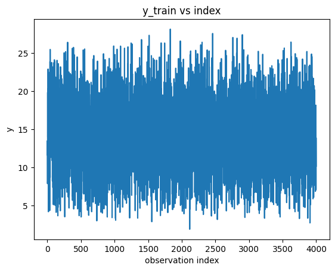

```python
# Is y_train sorted by group?
plt.plot(y_train)
plt.xlabel('observation index')
plt.ylabel('y')
plt.title('y_train vs index')
plt.show()
```

Our checks here show us:

- GroupKFold was correctly implemented: group_id excluded from features, dimensions verified (4000×40), y not standardised, and manual fold-by-fold verification confirmed the CV MSE of 1.04 is genuine and not a GridSearchCV artefact.
- The MSE of 1.04 violates the theoretical within-lab variance floor of 4.54. This could be overfitting, or finding non-linear feature interactions that can identify labs in high-dimensional spaces.

### 2.4 Model Interpretation: Coefficient and Feature Importance Comparison

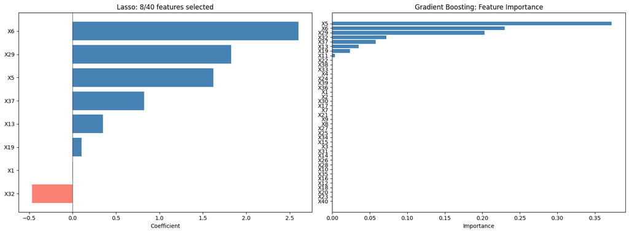

```
Top 5 Features:
Lasso:     ['X6', 'X29', 'X5', 'X37', 'X32']
GB:        ['X5', 'X6', 'X29', 'X32', 'X37']
```

```python
fig, axes = plt.subplots(1, 2, figsize=(16, 6))

# 1. Lasso coefficients
ax = axes[0]
nz = lasso_coefs[lasso_coefs != 0].sort_values()
ax.barh(nz.index, nz.values, color=['steelblue' if v > 0 else 'salmon' for v in nz])
ax.set_xlabel('Coefficient')
ax.set_title(f'Lasso: {len(nz)}/40 features selected')
ax.axvline(0, color='black', lw=0.5)

# 2. Gradient Boosting importance
ax = axes[1]
gb_imp_sorted = gb_importance.sort_values(ascending=True)
ax.barh(gb_imp_sorted.index, gb_imp_sorted.values, color='steelblue')
ax.set_xlabel('Importance')
ax.set_title('Gradient Boosting: Feature Importance')

plt.tight_layout()
plt.show()

# Cross-method agreement
print("Top 5 Features:")
print(f"Lasso:     {list(lasso_coefs.abs().sort_values(ascending=False).head(5).index)}")
print(f"GB:        {list(gb_importance.sort_values(ascending=False).head(5).index)}")
```

Both models select the correct features, verifying each other and reassuring our choices.

### 2.5 Model discussion

Although both models agree, we find that GB has wildly lower MSE scores, which is very suspicious behaviour.

We suspect this behavior stems from potentially two points:

1. Higher-dimension clustering: In higher dimensions, there may be clustering available that GB is able to exploit over Lasso.
2. GB is able to capture non-linearity, which could decode the batch effects here, and potentially correct for them. For example, if X6 > 0.55 AND X29 < 0.48 AND X37 > 0.52, then this looks like a high-y lab, so predict higher, regardless of clustering.

Point 2 raises an interesting problem however, if GB is doing this, then when presented with test data that GB has not been trained to correct, it may lead to inconsistent predictions, and potentially high stds.

## Part 3: Validation and Model Selection

From the assignment brief, test set contains samples from laboratories not present in training. Standard K-Fold CV randomly splits samples, so a training fold and validation fold would share samples from the same lab. Because labs have strong batch effects (Section 1.4), this would:

- Leak lab-specific information into the validation set
- Produce unrealistically low MSE estimates
- Select models that overfit to lab-specific patterns

GroupKFold solves this by ensuring entire laboratories are held out per fold, directly mimicking the test scenario.

### 3.2 Tuning Curves

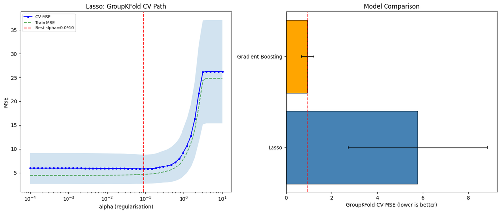

```python
fig, axes = plt.subplots(1, 2, figsize=(14, 6))

# Lasso CV path
ax = axes[0]
ax.semilogx(lasso_alphas, lasso_cv_mse, 'b-o', ms=3, label='CV MSE')
ax.fill_between(lasso_alphas, lasso_cv_mse - lasso_cv_std, lasso_cv_mse + lasso_cv_std, alpha=0.2)
ax.semilogx(lasso_alphas, lasso_train_mse, 'g--', alpha=0.6, label='Train MSE')
ax.axvline(best_lasso_alpha, color='r', ls='--', label=f'Best alpha={best_lasso_alpha:.4f}')
ax.set_xlabel('alpha (regularisation)')
ax.set_ylabel('MSE')
ax.set_title('Lasso: GroupKFold CV Path')
ax.legend(fontsize=8)

# Summary comparison bar chart
ax = axes[1]
model_names = list(results.keys())
mses = [results[m]['mse'] for m in model_names]
stds = [results[m]['std'] for m in model_names]
colors = ['steelblue'] * len(model_names)
best_idx = np.argmin(mses)
colors[best_idx] = 'orange'
ax.barh(model_names, mses, xerr=stds, color=colors, edgecolor='black', capsize=3)
ax.set_xlabel('GroupKFold CV MSE (lower is better)')
ax.set_title('Model Comparison')
ax.axvline(min(mses), color='red', ls='--', alpha=0.5)

plt.tight_layout()
plt.show()
```

### 3.3 Final Comparison Table

```python
print("-" * 70)
print(f"{'Model':<22} {'CV MSE':>10} {'± Std':>10} {'CV RMSE':>10} {'CV R^2':>10}")
print("-" * 70)

total_var = np.var(y_train)
for name in results:
    mse = results[name]['mse']
    std = results[name]['std']
    rmse = np.sqrt(mse)
    r2_cv = 1 - mse / total_var
    print(f"{name:<22} {mse:>10.4f} {std:>10.4f} {rmse:>10.4f} {r2_cv:>10.4f}")

print("-" * 70)
best_model_name = min(results, key=lambda m: results[m]['mse'])
print(f"\nBest model: {best_model_name} (lowest GroupKFold CV MSE)")
print(f"Estimated generalisation MSE: {results[best_model_name]['mse']:.4f}")
print(f"Estimated generalisation RMSE: {np.sqrt(results[best_model_name]['mse']):.4f}")
print(f"Estimated generalisation R^2: {1 - results[best_model_name]['mse']/total_var:.4f}")

# Also compute training metrics for overfitting analysis
print(f"\n{'Model':<22} {'Train MSE':>10} {'Train R^2':>10} {'CV MSE':>10} {'Gap':>10}")
print("-" * 70)
for name in results:
    model = results[name]['model']
    y_pred_train = model.predict(X_train)
    tr_mse = mean_squared_error(y_train, y_pred_train)
    tr_r2 = r2_score(y_train, y_pred_train)
    cv_mse = results[name]['mse']
    gap = cv_mse - tr_mse
    print(f"{name:<22} {tr_mse:>10.4f} {tr_r2:>10.4f} {cv_mse:>10.4f} {gap:>10.4f}")
```

```
----------------------------------------------------------------------
Model                      CV MSE      ± Std    CV RMSE      CV R²
----------------------------------------------------------------------
Lasso                      5.7816     3.0508     2.4045     0.7677
Gradient Boosting          0.9357     0.2665     0.9673     0.9624
----------------------------------------------------------------------

Best model: Gradient Boosting (lowest GroupKFold CV MSE)
Estimated generalisation MSE: 0.9357
Estimated generalisation RMSE: 0.9673
Estimated generalisation R^2: 0.9624

Model                   Train MSE   Train R²     CV MSE        Gap
----------------------------------------------------------------------
Lasso                      4.7247     0.8102     5.7816     1.0570
Gradient Boosting          0.1515     0.9939     0.9357     0.7842
```

Gradient Boosting achieves CV MSE = 0.94 (R^2 = 0.96) compared to Lasso's 5.78 (R^2 = 0.77).

As discussed earlier, this could come from two points:

1. Higher-dimension clustering: In higher dimensions, there may be clustering available that GB is able to exploit over Lasso.
2. GB is able to capture non-linearity, which could decode the batch effects here, and potentially correct for them. For example, if X6 > 0.55 AND X29 < 0.48 AND X37 > 0.52, then this looks like a high y lab, so predict higher, regardless of clustering.

Investigation could be done through analysing higher PCs, or constructing metrics on variance within labs. None of these were covered in the course materials, so we refrain from trying to explore new investigation methods.

This batch "correction" is learned from 40 training labs, so whether it transfers to new labs is the primary risk. However, the GroupKFold estimate is unbiased and the train-CV gap is modest, so we select GB as the final model.

## Part 4: Test Predictions

```python
best_model_name = min(results, key=lambda m: results[m]['mse'])
final_model = results[best_model_name]['model']

print(f"Selected model: {best_model_name}")
print(f"Estimated generalisation MSE: {results[best_model_name]['mse']:.4f}")

final_model.fit(X_train, y_train)

# Training performance
y_train_pred = final_model.predict(X_train)
train_mse = mean_squared_error(y_train, y_train_pred)
train_r2 = r2_score(y_train, y_train_pred)
print(f"\nTraining MSE: {train_mse:.4f}")
print(f"Training R^2:  {train_r2:.4f}")

y_hat = final_model.predict(X_test)

predictions = pd.DataFrame({
    'obs_id': test['obs_id'],
    'y_hat': y_hat
})

print(f"\nPrediction summary:")
print(f"  Rows:    {len(predictions)}")
print(f"  Columns: {list(predictions.columns)}")
print(f"  y_hat mean: {predictions['y_hat'].mean():.3f} (training y mean: {y_train.mean():.3f})")
print(f"  y_hat std:  {predictions['y_hat'].std():.3f} (training y std: {y_train.std():.3f})")
print(f"  y_hat range: [{predictions['y_hat'].min():.3f}, {predictions['y_hat'].max():.3f}]")

# Save
save_name = "final_predictions.csv"
predictions.to_csv(save_name, index=False)
print(f"\nSaved: {save_name}")
print(predictions.head(10))
```

```
Selected model: Gradient Boosting
Estimated generalisation MSE: 0.9357

Training MSE: 0.1515
Training R^2:  0.9939

Prediction summary:
  Rows:    1000
  Columns: ['obs_id', 'y_hat']
  y_hat mean: 14.275 (training y mean: 14.506)
  y_hat std:  6.015 (training y std: 4.989)
  y_hat range: [1.411, 26.075]

Saved: final_predictions.csv
   obs_id     y_hat
0       1  7.185956
1       2  5.914319
2       3  4.511198
3       4  6.176297
4       5  5.772921
5       6  4.485422
6       7  7.750143
7       8  3.629730
8       9  4.291734
9      10  8.530697
```